## Importing Necessary Packages

```python
import numpy as np
import matplotlib.pyplot as plt
```

# Problem 1:

**Problem:** Now suppose that each atom in the metal can point in three directions: $\uparrow$, $\rightarrow$, and $\downarrow$, corresponding to energy levels $-\mu_BB$, $0$, and $\mu_BB$. (Note that I am no longer saying electrons, because electrons have spin-$1/2$, so can't take on three values. Rather, one can imagine that the atomic spin is a combination of nuclear and electronic contributions). Derive expressions for the probabilities for the three spin orientations. **Important note:** you'll be left with two equations ($p_1+p_2+p_3=1$ and the total energy equation) and three unknowns ($p_1$, $p_2$, and $p_3$). But at equilibrium the entropy is a maximum, so you can get a third equation by insisting that $dS/dp_3=0$. Using these, repeat the procedure from part (b) above to obtain (and plot) the probabilities, magnetization, total energy, and the entropy as a function of $\tilde{T}$ at fixed $B$.

## Part 1a - Deriving Probability Equations and Proving Their Validity

The first portion of this problem is that we must dervive expressions for the probabilities of the **three** spin orientations. Without going into the complete derivation here (i'm sure my fingers would fall off typing this) we can just outline the final results. To start,we solved for $P_3$ in terms of U. This yielded the following result:

$$ p_3 = \frac{1}{6}\left( - \sqrt{4-3\left( \frac{U}{N\epsilon}\right)^2} + 3\left( \frac{U}{N\epsilon}\right) +4\right) $$

Which, we can re-arrange for the system's internal energy $U$ as follows:

$$ U = \frac{N \epsilon}{2}\left( -\sqrt{4p_3 -3p_3^2} +3p_3 -2\right) $$

And from our initial equations it can be shown that it is possible to express $p_1(p_3,U)$ and $p_2(p_3,U)$ as follows:

\begin{equation} p_1 = p_3 - \frac{U}{N \epsilon} \end{equation}$$ p_2 = 1 - 2p_3 + \frac{U}{N \epsilon} $$

And if we substitute in our expression for U into our expressions for $p_1$ and $p_2$ we find the following:

$$ p_1 = p_3 - \frac{1}{2}\left( - \sqrt{4p_3 - 3p_3^2} + 3p_3 - 2\right) $$$$ p_2 = 1 - 2p_3 \frac{1}{2} + \left( - \sqrt{4p_3 -3p_3^2} \right) $$

Now, before we proceed I wish to draw your attention to the negative sign in fornt of the square root term (that being $-\sqrt{4p_3 - 3p_3^2}$). If we look at any of our solutions (mainly the one described by p_3) we can see that it has the form of a solution that is quadratic in nature (i.e the solution was pulled from the quadratic formula). If you were to make this inference you would be correct, because using the quadratic formula was the last step ind eriving $p_3$. However, if you are familiar with the quadratic formula you know that it comes in the following form:

\begin{equation} x = \frac{- b \pm \sqrt{b^2 - 4ac}}{2a} \end{equation}

So clearly, in our solutions we chose the NEGATIVE value for the square root. How did we come about this solution? Well, that is what I will look to explain.

To start, we know that we have an expression for $U$ in terms of $p_3$. But, how would we expect this value to behave in the range where $0 \leq p_3 \leq 1$>? Well, recall that $p_3$ is representitive of the **spin-down** probability, i.e it has an energy given by:

$$ \epsilon = -1 $$

We know that when the probability of $p_3$ is equivalent to 1 (i.e all spins will be pointing down) that we are in the HIGHEST energy state. Recall from the previous assignment that we showed the spin system had a maximixed negative energy for temperature values close to 0. This means that we would expect energy to be maximized when $p_3 = 1$. What about the other extreme, when temperature is extremely large, what do we expect there? Well, we know from our previous assignment that a spin-1/2 system had the probabilities of being spin up or down approach 0.5 as $ T \to \infty$, this means that the energy will approach a MINIMUM or ZERO because there are an equal number of spin-up and spin-down states. So, how would the spin-1 system behave? Well, we know that there are three outcomes (i.e $\uparrow$, $\rightarrow$, and $\downarrow$) and that the energy must approach a minimum as $T \to \infty$. Thereby, we can infer that the probabilities of all three states will be equivalent and equal to the following:

$$ p_1 = p_2 = p_3 = 0.3333\bar{3} $$

```python
# Plotting p3 as a function of U
N = 10000
e = -1

# Storing the energy and p3 values
positive_uvals = []
p3_list = []

# Generating the values of U as a function of p_3
for u in np.arange(-N,0,1):
  p3 = (1/6)*(1*np.sqrt(4-3*(u/(N*e))**2) + 3*(u/(N*e)) + 4)
  p3_list.append(p3)
  positive_uvals.append(u)
```

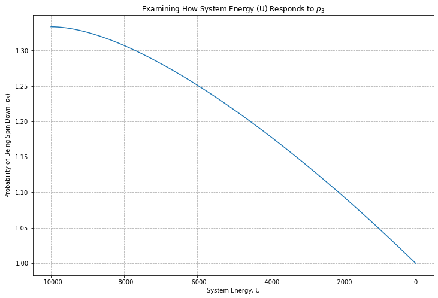

```python
#Plotting Labels
plt.figure(figsize=(12,8))
plt.xlabel('System Energy, U')
plt.ylabel('Probability of Being Spin Down, $p_3$)')
plt.title('Examining How System Energy (U) Responds to $p_3$')
plt.grid(linestyle='dashed')

#Plot the Function
plt.plot(positive_uvals , p3_list)
```

An immediate problem with this curve is the probability of $p_3$ goes above 1, which we know is NOT possible. Second, the probability of having $p_3 = 1$ when the system energy $U$ is minimzed. We know that this too is completely incorrect. As such, allow us to look at the solutions for the negative quadratic solution.

```python
# Plotting p3 as a function of U
N = 10000
e = -1

# Storing the energy and p3 values
negative_uvals = []
p3_list = []

# Generating the values of U as a function of p_3
for u in np.arange(-N,0,1):
  p3 = (1/6)*(-1*np.sqrt(4-3*(u/(N*e))**2) + 3*(u/(N*e)) + 4)
  p3_list.append(p3)
  negative_uvals.append(u)
```

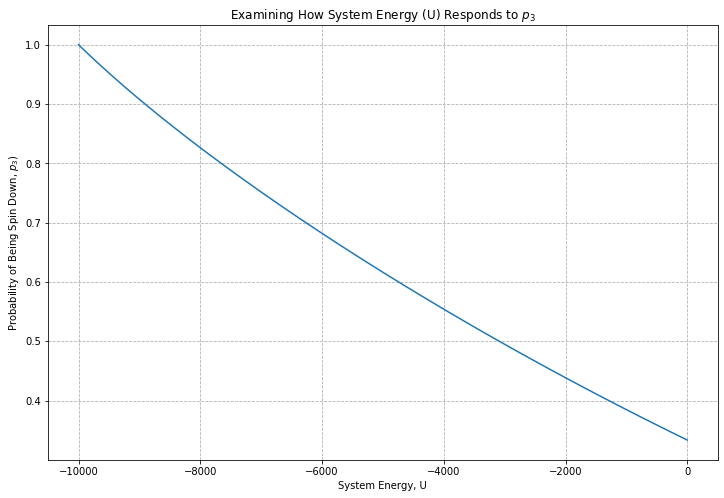

```python
#Plotting Labels
plt.figure(figsize=(12,8))
plt.xlabel('System Energy, U')
plt.ylabel('Probability of Being Spin Down, $p_3$)')
plt.title('Examining How System Energy (U) Responds to $p_3$')
plt.grid(linestyle='dashed')

#Plot the Function
plt.plot(negative_uvals , p3_list )
```

And there we have it, our expected probability curve! This indicates that we have proven the following relationships:

$$ p_3 = \frac{1}{6}\left( - \sqrt{4-3\left( \frac{U}{N\epsilon}\right)^2} + 3\left( \frac{U}{N\epsilon}\right) +4\right) $$

and

$$ U = \frac{N \epsilon}{2}\left( -\sqrt{4p_3 -3p_3^2} +3p_3 -2\right) $$

As such, we have shown that our derived equations match expected theory. As such, our next step will be to calculate the temperature of the system so that we can make the various plots that were requested in this question.

## Part 1b - Deriving Temperature

Recall that we can calculate the temperature via the followig equation:

\begin{equation} T = \frac{\partial U}{\partial S} \end{equation}

\begin{equation} \tilde{T} \approx \frac{\tilde{U}(p_3+\Delta p_3)-\tilde{U}(p_3)}{\tilde{S}(p_3+\Delta p_3)-\tilde{S}(p_3)} \end{equation}

As such, for us to solve this integral we must first generate two lists:

1. System Energy ($U$)
2. System Entropy ($S$)

Luckily, in our previous section we have already determined the system energy $U$ as a function of $p_3$, so we already have list (1). That means that all we are required to do is calculate the entropy for all given $p_3$'s, which can be done using the following equation:

\begin{equation} S = -N \left[ p_1 ln(p_1) + p_2 ln(p_2) + p_3ln(p_3)\right] \end{equation}

As such, for us to create a list of entropies we must first compute the probabilities of $p_1$, $p_2$ and $p_3$ as a function of U. This will allow us to easily calculate the entropy because at a given value of $U$ we will know the corresponding values of $p_1,p_2,p_3$ which will allow us to easily calculate an entropy value $S$ for the given $U$. As such, allow us to start by calculating the probabilities as a function of $U$:

```python
# Here I have just saved an energy list (i.e values of U) that will be used in our calculation of T
N = 10000
e = -1

# Storing values
energy_list = []
p3_list = []

# Calculating values of U for many values of p_3 between 0 and 1
for i in np.arange(0,1,0.0001):
  U = (1/2)*(1*np.sqrt(4*i-3*i**2)+3*i-2)*N*e
  energy_list.append(U)
  p3_list.append(i)
```

```python
# Allow us to just print the energy values to make sure that they make sense
print(energy_list)
```

[output not shown]

Again, we can calculate the values of $p_1$, $p_2$ and $p_3$ as follows:

```python
# Plotting p3 as a function of U
N = 10000
e = -1

# Storing all related values
uvals = []
p3_list = []
p2_list = []
p1_list = []
summed_list = []

# Determining the values of p3, p2 and p1 from the range of internal energies that we calculate above
for u in np.arange(-N,0,1):

  # Calculating probability values
  p3 = (1/6)*(-1*np.sqrt(4-3*(u/(N*e))**2) + 3*(u/(N*e)) + 4)
  p1 = p3 - u/(N*e)
  p2 = 1 - p1 - p3
  summed = p3 + p2 + p1

  # Appending these values to lists for later usage
  p3_list.append(p3)
  p2_list.append(p2)
  p1_list.append(p1)
  uvals.append(u)
  summed_list.append(summed)
```

And as such, we can plot the probabilities for a given system energy as follows:

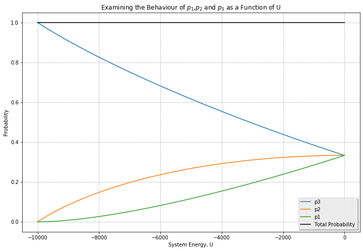

```python
#Plotting Labels
plt.figure(figsize=(12,8))
plt.xlabel('System Energy, U')
plt.ylabel('Probability')
plt.title('Examining the Behaviour of $p_1$,$p_2$ and $p_3$ as a Function of U')
plt.grid(linestyle='dashed')

#Plot the Function
plt.plot(uvals , p3_list , label = 'p3')
plt.plot(uvals , p2_list , label = 'p2')
plt.plot(uvals , p1_list , label = 'p1')
plt.plot(uvals , summed_list , label = 'Total Probability', color = 'black')

legend = plt.legend(loc = 4, shadow = 'true')
frame = legend.get_frame()
frame.set_alpha(0.8)
```

And there we have it, all the probability values $p_3$, $p_2$ and $p_1$ as a function of the total energy $U$. I have added the black line labelled "Total Probability" to show that the sum of the probabilities is equivalent to 1 as expected (as $p_1 + p_2 + p_3 = 1$ for all values of $U$). Now, allow us to go ahead and use these values, along with our entropy expression, to calculate a list of entropy values for a given value of $U$. To start, I will define a function that calculate the entropy of the system:

```python
def entropy(p1,p2,p3,N):

  """

  -- How it Works --

  This functions utilizes the entropy equation given above to calculate the entropy for a given value of p3.
  This function assumes that the values of p1 and p2 also correspond to the value of p3 (i.e they are the
  the probabilties for a given system energy U).

  -- Arguments --

  p1 = The probability of being spin up
  p2 = The probability of being spin "sideways"
  p3 = The probability of being spin down
  N = The number of units in your spin-1 pauli paramagnet

  """

  return -N*(p1*np.log(p1) + p2*np.log(p2) + p3*np.log(p3))
```

and finally, we can use this function to create our list of entropy values!

```python
# Here we are simply making an entropy list that will be used later to calculate the system temperature
N = 10000
entropy_list = []

# Calculating the entropy at a given internal energy U
for p1,p2,p3 in zip(p1_list,p2_list,p3_list): # running through all 3 probability lists simultaneously
  tropy = entropy(p1,p2,p3,N)
  entropy_list.append(tropy)
```

To double check that our results make sense allow us to plot the entropy as a function of the system energy. We would expect that when the system energy is maximized (i.e $U = - N$) that the entropy will be at a minimum ($S=0$). The reason for this being that all units of the spin-1 pauli paramagnet are down, indicating that there is no randomization as to the spin order. At the other extreme, when system energy is minimized ($U=0$) we would expect the entropy to maximized as the spins are all equally probable. As such:

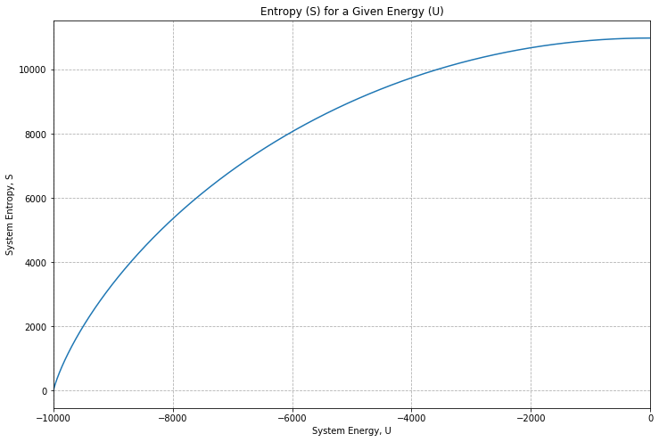

```python
#Plotting Labels
plt.figure(figsize=(12,8))
plt.xlabel('System Energy, U')
plt.ylabel('System Entropy, S')
plt.title('Entropy (S) for a Given Energy (U)')
plt.grid(linestyle='dashed')
plt.xlim(-10005,0)

#Plot the Function
plt.plot(negative_uvals, entropy_list)
```

And there we have it, our plot is exactly as we anticipated. As such, all that is left to do is to calculate the temperature for a given $U$ and $S$. This can be done with the following function:

```python
def temperature_calc3r(u_val_list,s_val_list):


  """

  -- How it Works --

  This function is used to calculate the temperature as has been defined above.

  -- Arguments --

  u_val_list = The energy values list
  s_val_list = The list of entropy values corresponding to the energy list

  """

  # Storing all calculated T values
  T_list = []

  # Using the afformentioned expression to calculate T
  for i in range(len(u_val_list)-1):
    T = (u_val_list[i+1]-u_val_list[i])/(s_val_list[i+1]-s_val_list[i])
    T_list.append(T)

  T_list.append(T_list[-1]) # Removing the last value of the list so that it is the same size as the other functions

  return T_list
```

```python
# Storing our temperature values and making sure that they return the expected results
temperature = temperature_calc3r(energy_list[::-1],entropy_list)
print(temperature)
```

[output not shown]

Finally, we have all the tools that are necessary to derive the plots that have been asked of us in this question. As such, allow us to start with the entropy.

## Part 1c: Deriving Plots

### Plotting Entropy

The first step is plot the systems entropy as a function of temperature, this can easily be done by calling upon the lists we have previously derived. As such, we find that:

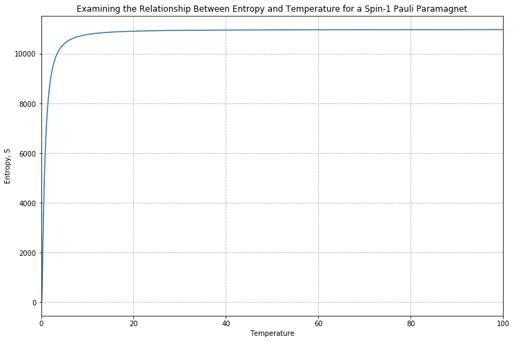

```python
# Plotting Entropy

#Plotting Labels
plt.figure(figsize=(12,8))
plt.xlabel('Temperature')
plt.ylabel('Entropy, S')
plt.title('Examining the Relationship Between Entropy and Temperature for a Spin-1 Pauli Paramagnet')
plt.grid(linestyle='dashed')
plt.xlim(0,100)

#Plot the Function
plt.plot(temperature , entropy_list )
```

Which is exactly what we had seen before. Please note that this entropy is expected, as it obeys the following relationship:

$ S \propto ln\left( X^N\right) $

Where $X$ is the number of spin possibilities and $N$ is the number of units (or electrons), as such, for our spin-1 paramagnet we find that the maximized entropy is:

$ S \propto ln\left( 3^N\right) $

Note that this is only in the limit of $\tilde{T} \to \infty$ (although $\tilde{T}$ doesn't even need to be that large to meet this criterion).

### Plotting Energy

Now, we can follow the same process as above but now we will plot the system energy $U$ as a function of temperature $T$.

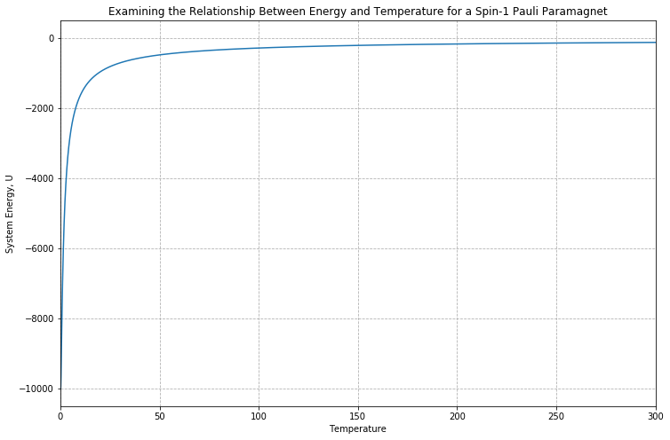

```python
# Plotting Entropy

#Plotting Labels
plt.figure(figsize=(12,8))
plt.xlabel('Temperature')
plt.ylabel('System Energy, U')
plt.title('Examining the Relationship Between Energy and Temperature for a Spin-1 Pauli Paramagnet')
plt.grid(linestyle='dashed')
plt.xlim(0,300)

#Plot the Function
plt.plot(temperature , uvals )
```

Which again is exactly what we expect. As temperature increases the spins will not be highly correlated and there will be an equal number of spin up, "sideways" and down. This means that for large values of $\tilde{T}$ (i.e $\tilde{T} \to \infty$) the energy will be roughly equivalent to zero, which is exactly what we see here.

### Plotting Magnetization

Before we can plot the magnetization we must first calculate it. We can do this by simply utilizing the following expression:

$$ M = N tanh \left( \frac{\tilde{B}}{\tilde{T}}\right) $$

Where we can set the magnetic field $\tilde{B}$ to any arbitrary integer that we choose. For fun let us just set it as: $\tilde{B} = 10$.

```python
def magnetization(B,T,N):

  """

  -- How it Works --

  This function simply calculates the magnetization of a pauli paramagnet by using
  the equation defined above.

  -- Arguments --

  B = The magnetic field
  T = The temperature for which we wish to calculate the net magnetization of the paramagnet
  N = The number of units (electrons) in the magnet

  """

  return N*np.tanh(B/T)
```

And we can calculate our values of magnetization below as follows:

```python
# We have 10,000 electrons and recall that we set B=10
N = 10000
B = 10

# Storing magnetization values
mag_list = []

# Calculating magnetization values using the above function
for T in temperature:
  mag = magnetization(B,T,N)
  mag_list.append(mag)
```

And finally, we can go ahead and plot these values:

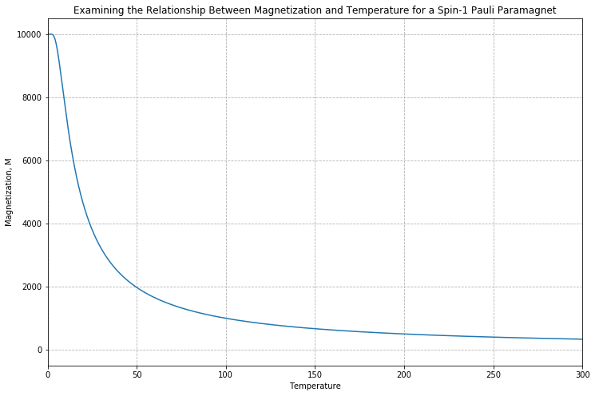

```python
# Plotting Entropy

#Plotting Labels
plt.figure(figsize=(12,8))
plt.xlabel('Temperature')
plt.ylabel('Magnetization, M')
plt.title('Examining the Relationship Between Magnetization and Temperature for a Spin-1 Pauli Paramagnet')
plt.grid(linestyle='dashed')
plt.xlim(0,300)

#Plot the Function
plt.plot(temperature , mag_list)
```

Which is exactly as we saw in the first assignment, as is expected! As the spins become more random we will steadily see the magnetization decrease to zero (as the number of spin up and spin down electrons will roughly be equivalent).

## Plotting Probabilities

Again, all we need to do is plot the probabilities as a function of temperature. Since we already derived probability lists all we are required to do is plot them as a function of temperature.

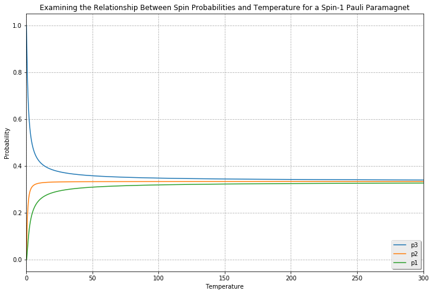

```python
#Plotting Labels
plt.figure(figsize=(12,8))
plt.xlabel('Temperature')
plt.ylabel('Probability')
plt.title('Examining the Relationship Between Spin Probabilities and Temperature for a Spin-1 Pauli Paramagnet')
plt.grid(linestyle='dashed')
plt.xlim(0,300)

#Plot the Function
plt.plot(temperature , p3_list , label = 'p3')
plt.plot(temperature , p2_list , label = 'p2')
plt.plot(temperature , p1_list , label = 'p1')

legend = plt.legend(loc = 4, shadow = 'true')
frame = legend.get_frame()
frame.set_alpha(0.8)
```

And as expected, as temperature increases the probabilities steadily become equivalent to one another. Note how initially the spins have a 100% chance of being spin-down. This is because in a positive $\tilde{B}$ - which is the condition that we are currently under - spin-down is the lowest energy state, and thereby the most preferred state.

# Problem 2:

**Problem:** Return to the Pauli paramagnet, Problems 3.4.2, for the cases (i) spin-$1/2$ (spins $\uparrow$ and $\downarrow$), and (ii) spin-1 (spins $\uparrow$, $\rightarrow$, and $\downarrow$). Construct the partition functions, and obtain the probabilities, total energy, and entropy as a function of temperature. Notes: don't worry about randomly sampling spins; just numerically evaluate the above quantities. Also, it's easier to calculate the derivate on the partition function anaytically first, rather than calculating the derivative numerically.

We can express the probability of being in a given state $i$ within the canonical ensemble as follows:

$$p_i={n_i\over N}={A\exp(-\epsilon_i/k_BT)\over A\sum_i\exp(-\epsilon_i/k_BT)}\equiv{\exp(-\epsilon_i/k_BT)\over Z},$$

where the **partition function**, $Z$ is defined as:

$$Z\equiv\sum_i\exp\left(-{\epsilon_i\over k_BT}\right).$$

To start, allow us to construct the spin 1/2 pauli paramagnet. That is, we have spins $\uparrow$ and $\downarrow$ with the energies corresponding to the following:

$$ \epsilon_{\pm 1}=\pm\mu_BB \:\: If \:\: B>0$$

To start, we will want to construct the probability of being spin down ($p_1$) or the probability of being spin up ($p_2$) for a given temperature $\tilde{T}$ and magnetic field $\tilde{B}$.

## Spin-1/2 Pauli Paramagnet

### Probabilities

```python
def partition_calc3r( energies , T ):

  """

   Remember: just have a function perform one task, do not loop through in here.
   Will make things complicated if I do.

  """
  # Stroring the energy values in a list
  NRG = energies

  # Partition function is initially zero
  Z = 0

  for e in NRG: # Calculating the individal exponentials in the partition function
    Z_e = np.exp(- (e/T) )
    Z += Z_e

  return Z # Returning the final result for the partition function
```

Now, allow us to test the partition function calculator to make sure that it is returning the expected results:

```python
energies = np.array([1,-1]) # The energies that we will be passing through
z_list = []

for T in np.arange(0.1,10,0.1):
  result = partition_calc3r( energies , T )
  z_list.append(result)

print(z_list)
```

```
[22026.46584020665, 148.4198970495757, 28.067298887873378, 12.264578959327372, 7.524391382167263, 5.483365653307591, 4.412384920039871, 3.7768477543220316, 3.3669247653253884, 3.0861612696304874, 2.884955406152145, 2.7355740993999027, 2.6214749031796205, 2.532268729823095, 2.4611511600872675, 2.4035…
```

And the function behaves as expected. We Start at an extremely large value for Z at low values of T, which eventually decreases steadily until it reaches an asymtote. Recall that the purpose of the partition function is to normalize the probability distribution, so it must run through all possible energies. However, our probability calculator is only required to consider one energy at a time (i.e $\epsilon_i$). Now, allow us to create a function that will determine the probabilities of a given spin up or spin down:

```python
def probability_calc3r( energies, T ):

  """


  """

  # We want to start by calculating the partition function
  Z = partition_calc3r( energies , T )

  probabilities = []

  # Calculating the probability for each given energy
  for e in energies:
    probabilities.append( np.exp(-(e/T))/Z )

  return probabilities
```

```python
eng = np.array([-1,1])
T = 5
probability_calc3r(eng,T)
```

```
[0.598687660112452, 0.40131233988754794]
```

Again, allow us to determine the probabilities for a given temperature $\tilde{T}$:

```python
energies = np.array([-1,1]) # The energies that we will be passing through

p_list1 = []
p_list2 = []
T_list = []

# Here we are calculating the probabilities of being spin up or down at a given temperature
for T in np.arange(0.1,100,0.1):
  result1 = probability_calc3r( energies , T )[0] # Indicating spin down
  result2 = probability_calc3r( energies , T )[1] # Indicating spin up

  p_list1.append(result1)
  p_list2.append(result2)
  T_list.append(T)
```

Now, allow us to go through and attempt to plot everything (i.e the probability of being spin down as a function of temperature):

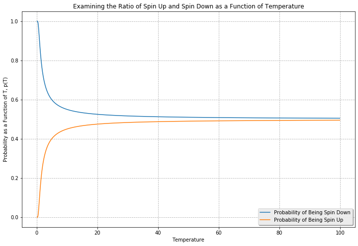

```python
#Plotting Labels
plt.figure(figsize=(12,8))
plt.xlabel('Temperature')
plt.ylabel('Probability as a Function of T, p(T)')
plt.title('Examining the Ratio of Spin Up and Spin Down as a Function of Temperature')
plt.grid(linestyle='dashed')

#Plot the Function
plt.plot(T_list, p_list1 , label = 'Probability of Being Spin Down')
plt.plot(T_list, p_list2 , label = 'Probability of Being Spin Up')

legend = plt.legend(loc = 4, shadow = 'true')
frame = legend.get_frame()
frame.set_alpha(0.8)
```

Please note that these probabilities are representing a POSITIVE $\tilde{B}$. This is because the electrons in the system have a propensity to be spin down, however, as we increase T this relationship is slowly weakened. The trends would be opposite for a NEGATIVE $\tilde{B}$.

### Total Internal Energy

We can calculate the total internal energy of the system by using the following equation:

\begin{equation} U=Nk_BT^2{\partial\ln(Z)\over\partial T}. \end{equation}

Where all we are required to do is to take the derivative of the partition function, which yields:

$$ \frac{\partial\ln(Z)}{\partial T} = \frac{\partial}{\partial T} ln\left[ \sum_i\exp\left(-{\epsilon_i\over k_BT}\right) \right] = \frac{1}{k_b} \sum_i \frac{\frac{\epsilon_i}{T^2}exp\left(-{\epsilon_i\over k_BT} \right)}{exp(-\frac{\epsilon_i}{k_b T})} $$

As such, we may express the total energy as follows:

$$ U=Nk_BT^2\left[ \frac{1}{k_b} \sum_i \frac{\frac{\epsilon_i}{T^2}exp\left(-{\epsilon_i\over k_BT} \right)}{exp(-\frac{\epsilon_i}{k_b T})}\right] = N T^2 \left[ \sum_i \frac{\frac{\epsilon_i}{T^2}exp\left(-{\epsilon_i\over k_BT} \right)}{exp(-\frac{\epsilon_i}{k_b T})}\right] $$

As such, allow us to make a unitless function with this result:

```python
def derivative_calc3r(energies,T):

  """

  This function calculates the derivative of ln(Z) with respect to T so that
  our energy function can be generalized for both the spin-1/2 and spin-1 pauli
  paramagnets.

  """

  numerator = 0
  denominator = 0

  for NRG in energies:
    numerator += (NRG*np.exp(-(NRG/T)))/(T**2)
    denominator += np.exp(-(NRG/T))

  return numerator/denominator
```

And finally, we can calculate the energy with our new derivative function:

```python
def en3rgy_calc3r( N , energies , T ):

  """

  -- How it Works --

  This function simply calculates the energy of the pauli-paramagnet

  -- Arguments --

  N = Number of electrons (units)
  energies = The energies of the spins
  T = The temperature of the paramagnet

  """

  dZ = derivative_calc3r(energies,T)

  return N*(T**2)*dZ # Calculating the final energy expresion
```

Say we have a lattice comprised of 10,000 electrons. In uassuming this, we can calculate the energies as follows:

```python
spin_energies = np.array([1,-1]) # The energies that we will be passing through
N = 10000
energy_list = []
T_list = []

for T in np.arange(0.1,100,0.01):
  result = en3rgy_calc3r( N , spin_energies , T )
  energy_list.append(result)
  T_list.append(T)
```

Which can be printed below as follows:

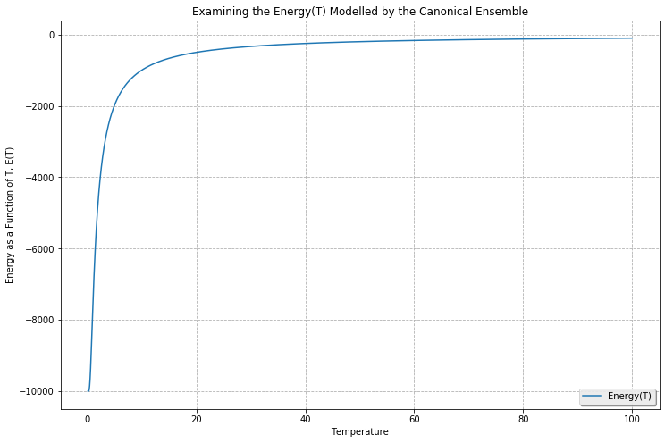

```python
#Plotting Labels
plt.figure(figsize=(12,8))
plt.xlabel('Temperature')
plt.ylabel('Energy as a Function of T, E(T)')
plt.title('Examining the Energy(T) Modelled by the Canonical Ensemble')
plt.grid(linestyle='dashed')

#Plot the Function
plt.plot(T_list, energy_list , label = 'Energy(T)')

legend = plt.legend(loc = 4, shadow = 'true')
frame = legend.get_frame()
frame.set_alpha(0.8)
```

### Entropy

Finally, we can calculate the entropy by using the following equation:

\begin{equation} S=Nk_B\ln(Z)+{ U\over T}. \end{equation}

Turning this into a unitless function yields:

```python
def entropy_calc3r( N , energies , T ):

  """


  """
  Z = partition_calc3r( energies , T )
  U = en3rgy_calc3r( N , energies , T )

  return N*np.log(Z) + U/T # Returning the expected entropy values
```

```python
spin_energies = np.array([1,-1]) # The energies that we will be passing through
N = 10000
entropy_list = []
T_list = []

for T in np.arange(0.1,100,0.01):
  result = entropy_calc3r( N , spin_energies , T )
  entropy_list.append(result)
  T_list.append(T)
```

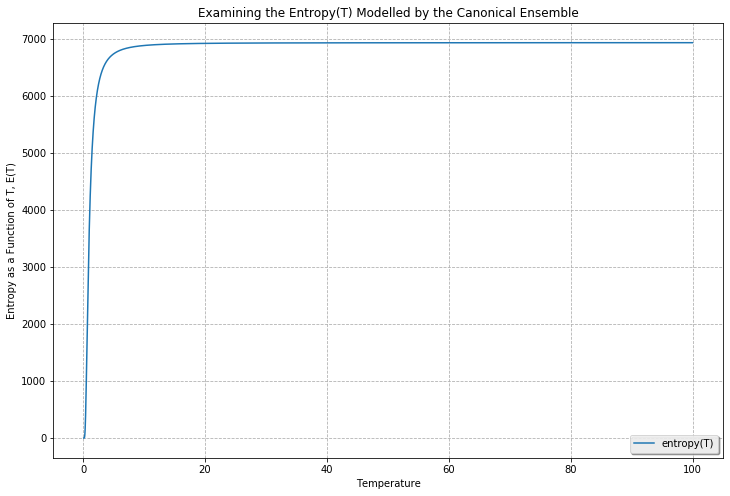

```python
#Plotting Labels
plt.figure(figsize=(12,8))
plt.xlabel('Temperature')
plt.ylabel('Entropy as a Function of T, E(T)')
plt.title('Examining the Entropy(T) Modelled by the Canonical Ensemble')
plt.grid(linestyle='dashed')

#Plot the Function
plt.plot(T_list, entropy_list , label = 'entropy(T)')

legend = plt.legend(loc = 4, shadow = 'true')
frame = legend.get_frame()
frame.set_alpha(0.8)
```

## Spin-1 Pauli Paramagnet

The spin-1 Pauli Paramagnet will be easy for us to calculate as all we are required to do is pass our functions 3 energies instead of two. These energies will be: -1 , 0 and 1. Plotting these functions, we find:

```python
# All we are doing here is saving values for plotting!

energies = np.array([-1,0,1]) # The energies that we will be passing through
N_val = 10000

p_list1 = []
p_list2 = []
p_list3 = []
energy_1_list = []
entropy_1_list = []
T_list = []

# Here we are calculating the probabilities of being spin up or down at a given temperature
for T in np.arange(0.1,100,0.01):

  # -- Deriving probability lists --
  result1 = probability_calc3r( energies , T )[0] # Indicating spin down
  result2 = probability_calc3r( energies , T )[1] # Indicating spin sideways
  result3  = probability_calc3r( energies , T )[2] # Indicating spin sideways
  p_list1.append(result1)
  p_list2.append(result2)
  p_list3.append(result3)

  # Calculating Energy Probabilities
  nrg_result = en3rgy_calc3r( N_val , energies , T )
  energy_1_list.append(nrg_result)

  # Calculating Entropy Probabilities
  ent_result = entropy_calc3r( N_val , energies , T )
  entropy_1_list.append(ent_result)

  # Appending Temperature values to plot against
  T_list.append(T)
```

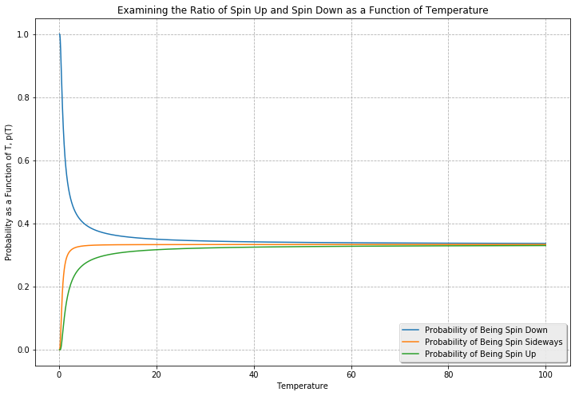

```python
#Plotting Labels
plt.figure(figsize=(12,8))
plt.xlabel('Temperature')
plt.ylabel('Probability as a Function of T, p(T)')
plt.title('Examining the Ratio of Spin Up and Spin Down as a Function of Temperature')
plt.grid(linestyle='dashed')

#Plot the Function
plt.plot(T_list, p_list1 , label = 'Probability of Being Spin Down')
plt.plot(T_list, p_list2 , label = 'Probability of Being Spin Sideways')
plt.plot(T_list, p_list3 , label = 'Probability of Being Spin Up')

legend = plt.legend(loc = 4, shadow = 'true')
frame = legend.get_frame()
frame.set_alpha(0.8)
```

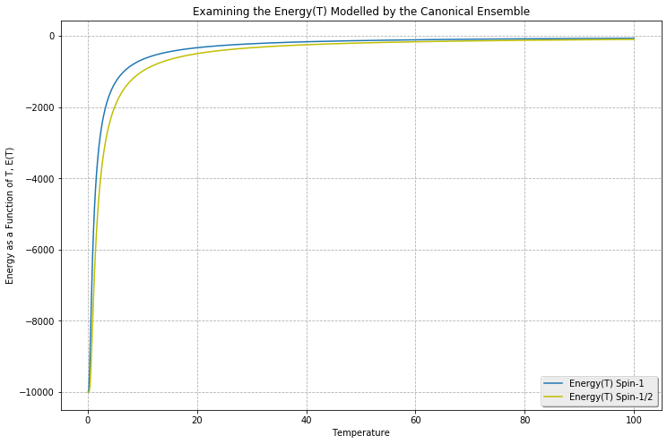

```python
#Plotting Labels
plt.figure(figsize=(12,8))
plt.xlabel('Temperature')
plt.ylabel('Energy as a Function of T, E(T)')
plt.title('Examining the Energy(T) Modelled by the Canonical Ensemble')
plt.grid(linestyle='dashed')

#Plot the Function
plt.plot(T_list, energy_1_list , label = 'Energy(T) Spin-1')
plt.plot(T_list , energy_list , color = 'y', label = 'Energy(T) Spin-1/2')

legend = plt.legend(loc = 4, shadow = 'true')
frame = legend.get_frame()
frame.set_alpha(0.8)
```

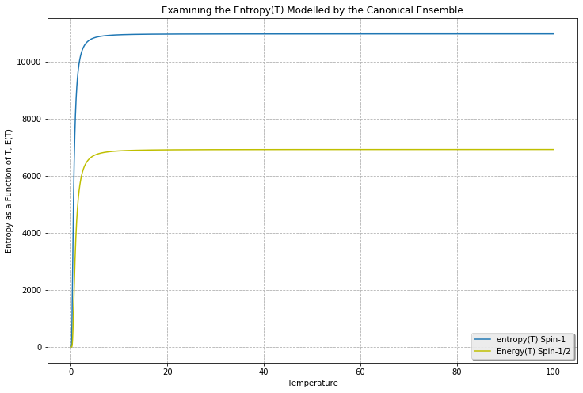

```python
#Plotting Labels
plt.figure(figsize=(12,8))
plt.xlabel('Temperature')
plt.ylabel('Entropy as a Function of T, E(T)')
plt.title('Examining the Entropy(T) Modelled by the Canonical Ensemble')
plt.grid(linestyle='dashed')

#Plot the Function
plt.plot(T_list, entropy_1_list , label = 'entropy(T) Spin-1')
plt.plot(T_list , entropy_list , color = 'y', label = 'Energy(T) Spin-1/2')
legend = plt.legend(loc = 4, shadow = 'true')
frame = legend.get_frame()
frame.set_alpha(0.8)
```

As such, we can see that the entropy for the spin-1/2 paramagnet is given by:

$$ S_{1/2} \propto ln\left( 2^N\right) $$

as it reaches its asymtote for high temperature. Whereas for the spin-1 paramagnet we see that the entropy at the asymtote is proportional to:

$$ S_1 \propto ln\left( 3^N \right) $$